# Lab2

## CSCN8010 - Foundations of Machine Learning

### Practical Lab 2: Multivariate Linear Regression, Non-Parametric Models and Cross-Validation

#### Name: Paljeet Singh Sambhi (Section 1)

#### Student ID: 8918495

#### Importing Libraries

```python
import pandas as pd
import numpy as np
from sklearn import datasets
import matplotlib.pyplot as plt
import seaborn as sns
from sklearn.preprocessing import PolynomialFeatures
from sklearn.linear_model import LinearRegression
from sklearn.pipeline import make_pipeline
from sklearn.model_selection import train_test_split
from sklearn.metrics import r2_score, mean_absolute_error, mean_squared_error
from sklearn.preprocessing import StandardScaler
from sklearn.tree import DecisionTreeRegressor
from sklearn.neighbors import KNeighborsRegressor
from scipy import stats
import warnings
warnings.filterwarnings('ignore')
```

#### The Problem

**Objective**: Build a model to predict the risk of diabetes progression one year after baseline. This prediction will serve as a screening tool for physicians to identify at-risk patients.

**Dependent Variable**: target - Disease progression one year after baseline.  
**Independent Variables**: 10 baseline variables such as age, sex, body mass index (BMI), average blood pressure, and six blood serum measurements.

#### EDA

```python
# Load the diabetes dataset
diabetes_data = datasets.load_diabetes()

# Create a DataFrame from the 'data'
df = pd.DataFrame(diabetes_data['data'], columns=diabetes_data['feature_names'])
# Add a column with the target
df['target'] = diabetes_data['target']
# Standardize the features
scaler = StandardScaler()
scaled_features = scaler.fit_transform(df)
# Convert back to DataFrame for better readability
scaled_df = pd.DataFrame(scaled_features, columns=df.columns)
```

```python
diabetes_data=scaled_df.copy()
diabetes_data.head()
```

|  | age | sex | bmi | bp | s1 | s2 | s3 | s4 | s5 | s6 | target |
| --- | --- | --- | --- | --- | --- | --- | --- | --- | --- | --- | --- |
| 0 | 0.800500 | 1.065488 | 1.297088 | 0.459841 | -0.929746 | -0.732065 | -0.912451 | -0.054499 | 0.418531 | -0.370989 | -0.014719 |
| 1 | -0.039567 | -0.938537 | -1.082180 | -0.553505 | -0.177624 | -0.402886 | 1.564414 | -0.830301 | -1.436589 | -1.938479 | -1.001659 |
| 2 | 1.793307 | 1.065488 | 0.934533 | -0.119214 | -0.958674 | -0.718897 | -0.680245 | -0.054499 | 0.060156 | -0.545154 | -0.144580 |
| 3 | -1.872441 | -0.938537 | -0.243771 | -0.770650 | 0.256292 | 0.525397 | -0.757647 | 0.721302 | 0.476983 | -0.196823 | 0.699513 |
| 4 | 0.113172 | -0.938537 | -0.764944 | 0.459841 | 0.082726 | 0.327890 | 0.171178 | -0.054499 | -0.672502 | -0.980568 | -0.222496 |

```python
diabetes_data.describe()
```

|  | age | sex | bmi | bp | s1 | s2 | s3 | s4 | s5 | s6 | target |
| --- | --- | --- | --- | --- | --- | --- | --- | --- | --- | --- | --- |
| count | 4.420000e+02 | 4.420000e+02 | 4.420000e+02 | 4.420000e+02 | 4.420000e+02 | 442.000000 | 442.000000 | 4.420000e+02 | 4.420000e+02 | 4.420000e+02 | 4.420000e+02 |
| mean | 8.037814e-18 | 1.607563e-17 | -2.813235e-17 | -1.607563e-17 | -8.037814e-18 | 0.000000 | 0.000000 | 1.607563e-17 | -8.037814e-18 | -1.607563e-17 | -1.687941e-16 |
| std | 1.001133e+00 | 1.001133e+00 | 1.001133e+00 | 1.001133e+00 | 1.001133e+00 | 1.001133 | 1.001133 | 1.001133e+00 | 1.001133e+00 | 1.001133e+00 | 1.001133e+00 |
| min | -2.254290e+00 | -9.385367e-01 | -1.897929e+00 | -2.363050e+00 | -2.665411e+00 | -2.430626 | -2.150883 | -1.606102e+00 | -2.651040e+00 | -2.896390e+00 | -1.650961e+00 |
| 25% | -7.841722e-01 | -9.385367e-01 | -7.196249e-01 | -7.706500e-01 | -7.200196e-01 | -0.638249 | -0.738296 | -8.303008e-01 | -6.989486e-01 | -6.975491e-01 | -8.458263e-01 |
| 50% | 1.131724e-01 | -9.385367e-01 | -1.531324e-01 | -1.192138e-01 | -9.084100e-02 | -0.080291 | -0.138431 | -5.449919e-02 | -4.093693e-02 | -2.265729e-02 | -1.510729e-01 |
| 75% | 8.005001e-01 | 1.065488e+00 | 6.569519e-01 | 7.493678e-01 | 5.961931e-01 | 0.627442 | 0.616239 | 7.213025e-01 | 6.818506e-01 | 5.869224e-01 | 7.709362e-01 |
| max | 2.327895e+00 | 1.065488e+00 | 3.585718e+00 | 2.776058e+00 | 3.235851e+00 | 4.179278 | 3.809072 | 3.894331e+00 | 2.808722e+00 | 2.851075e+00 | 2.517559e+00 |

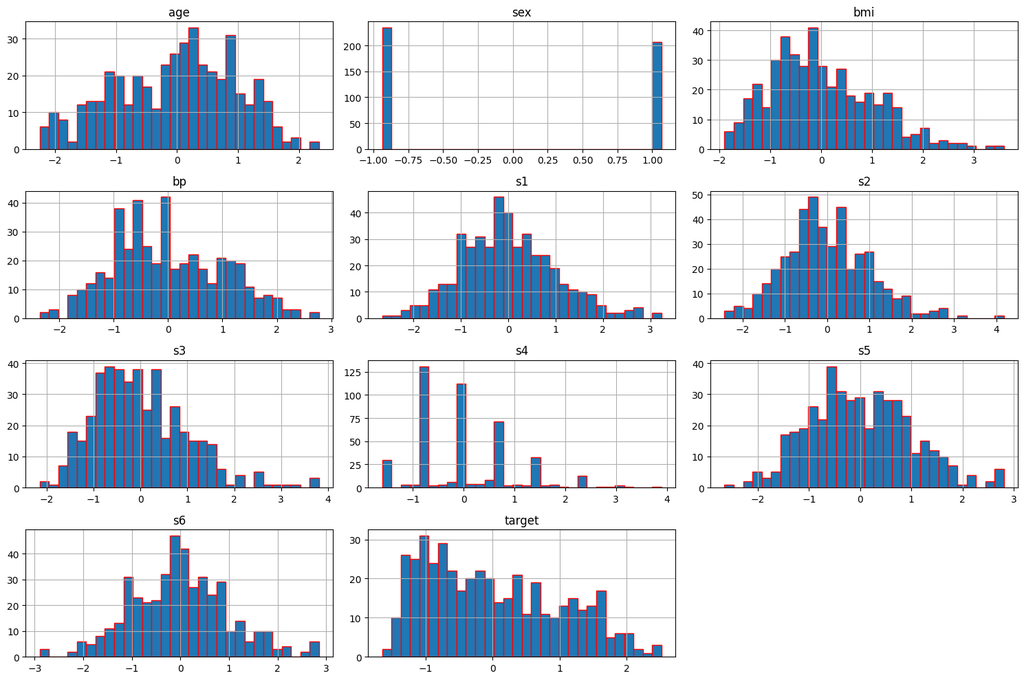

```python
# Create a pairplot of the DataFrame

diabetes_data.hist(bins=30, figsize=(15, 10) , edgecolor='red')
plt.tight_layout()
plt.show()
```

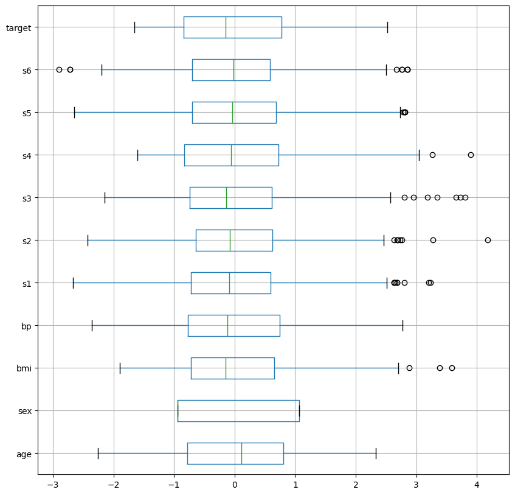

```python
# Create a boxplot
diabetes_data.boxplot(figsize=(10, 10) , vert=False)
```

```python
#Remove outliers using Z-score
df = diabetes_data.copy()

# Calculate the Z-scores
z_scores = np.abs(stats.zscore(df))

# Define a threshold
threshold = 3

# Filter out the outliers
df_filtered = df[(z_scores < threshold).all(axis=1)]

print("Original DataFrame:")
print(diabetes_data.shape)
print("\nFiltered DataFrame:")
print(df_filtered.shape)

diabetes_data = df_filtered.copy()
```

```
Original DataFrame:
(442, 11)

Filtered DataFrame:
(430, 11)
```

- After removing outliers we have 430 records.
- As seen in the boxplot we have some potential outliers so in order to remove those i performed z score removal method

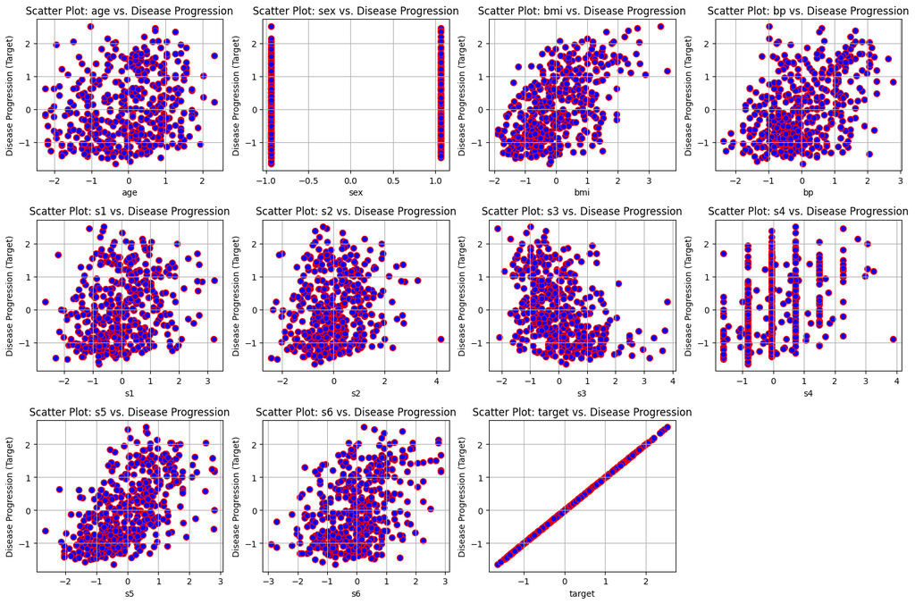

```python
# Plot the scatter plots
plt.figure(figsize=(15, 10))

# Loop through each feature to create subplots
for i, column in enumerate(diabetes_data.columns):
    plt.subplot(3, 4, i + 1)  # 3 rows, 4 columns of subplots
    plt.scatter(df[column], df['target'], color='blue', edgecolor='red', s=50)
    plt.title(f'Scatter Plot: {column} vs. Disease Progression')
    plt.xlabel(column)
    plt.ylabel('Disease Progression (Target)')
    plt.grid(True)

# Adjust layout for better spacing
plt.tight_layout()
plt.show()
```

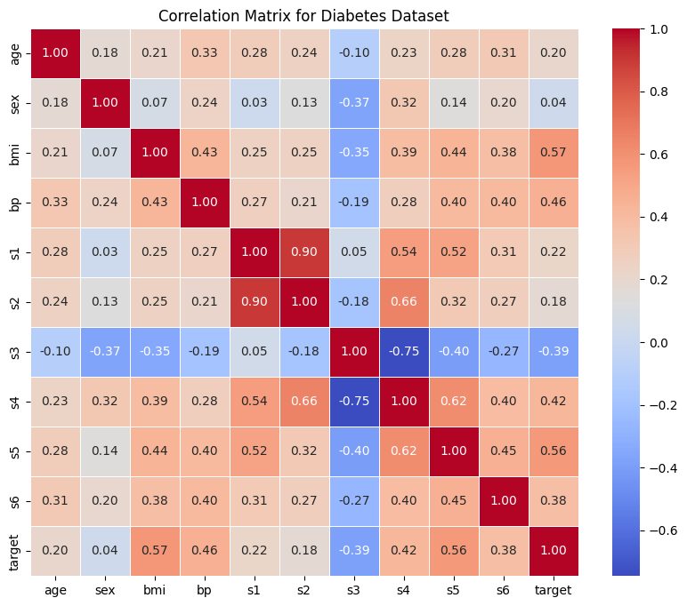

```python
# Calculate the correlation matrix
correlation_matrix = diabetes_data.corr()

# Visualize the correlation matrix using a heatmap
plt.figure(figsize=(10, 8))
sns.heatmap(correlation_matrix, annot=True, fmt=".2f", cmap='coolwarm', square=True, linewidths=0.5)

# Add titles and labels
plt.title('Correlation Matrix for Diabetes Dataset')
plt.show()
```

```python
# Example of interpreting the heatmap
correlation_matrix = diabetes_data.corr()

# Find pairs of highly correlated features
high_corr_pairs = [(i, j) for i in correlation_matrix.columns for j in correlation_matrix.columns if i != j and abs(correlation_matrix.loc[i, j]) > 0.8]

print("Highly correlated pairs:", high_corr_pairs)
```

```
Highly correlated pairs: [('s1', 's2'), ('s2', 's1')]
```

Remove to s2 cause the are the highly related features

```python
# drop s2 from the dataset
diabetes_data.drop(columns=['s2'], inplace=True)
```

```python
# Missing values, and irrelevant columns. Explain your reasoning for each step.
diabetes_data.isnull().sum()
```

```
age       0
sex       0
bmi       0
bp        0
s1        0
s3        0
s4        0
s5        0
s6        0
target    0
dtype: int64
```

### Part - 2

#### Models: a univariate polynomial regression on the BMI feature versus the "disease progression one year after baseline" - from degree 0 to 5

```python
# Split the data into features and target variable
X=diabetes_data[['bmi']]
y=diabetes_data[['target']]

X.shape, y.shape
```

```
((430, 1), (430, 1))
```

#### Train, validation and test split

```python
# First, split the data into training + validation (85%) and test set (15%)
X_train_val, X_test, y_train_val, y_test = train_test_split(X, y, test_size=0.15, random_state=42)

# Now, split the training + validation set into training (75%) and validation set (10%)
X_train, X_val, y_train, y_val = train_test_split(X_train_val, y_train_val, test_size=0.12, random_state=42)

# Print the sizes of the splits to verify
print(f"Training set size: {X_train.shape[0]} samples")
print(f"Validation set size: {X_val.shape[0]} samples")
print(f"Test set size: {X_test.shape[0]} samples")
```

```
Training set size: 321 samples
Validation set size: 44 samples
Test set size: 65 samples
```

#### Compare the models using the training and validation data. Construct a table summarizing the train validation results. Each model should have a separate row in the table

```python
# Create a list to store the results
results = []

# Make a function for polynomial regression
def polynomial_fit(X, y, degree, X_val=None, y_val=None):

    # Create the model
    model = LinearRegression()

    if degree != 0:  # 0 means no polynomial features
        poly_features = PolynomialFeatures(degree=degree, include_bias=False) # Linear regression with polynomial features
    else:
        poly_features = PolynomialFeatures(degree=degree, include_bias=True)  # Linear regression without polynomial features
    # Create the polynomial features
    X_train_poly = poly_features.fit_transform(X)
    # If validation data is provided, transform it as well
    if X_val is not None:
        X_val_poly = poly_features.transform(X_val)
    else:
        X_val_poly = None
    # Fit the model
    model.fit(X_train_poly, y)
    # Predict the target on the validation data
    y_val_pred = model.predict(X_val_poly)

    # Calculate the metrics
    mape = np.mean(np.abs((y_val - y_val_pred) / y_val)) * 100
    r2 = r2_score(y_val, y_val_pred)
    mae = mean_absolute_error(y_val, y_val_pred)

    # Store the results
    results.append((degree, r2, mae, mape))
    # Return the model
    return model
```

```python
# Create a list to store the models
models_univariate_Polynomial = []

results = []
#loop through the degrees
for degree in range(0,6):
    models_univariate_Polynomial.append(polynomial_fit(X=X_train, y=y_train, degree=degree, X_val=X_val, y_val=y_val))
# Create a DataFrame from the results
data = pd.DataFrame(results, columns=['Degree', 'R-Squared', 'MAE' , 'MAPE'])
# Display the results in a table
print(data)
```

```
   Degree  R-Squared       MAE        MAPE
0       0  -0.109555  0.809876  104.650903
1       1   0.103913  0.755408  199.265991
2       2   0.104379  0.755186  199.125995
3       3   0.088304  0.754605  205.363953
4       4   0.088977  0.749049  209.592382
5       5   0.099736  0.744229  206.786621
```

```python
# Identify the best model based on R2 (maximum R2 value)
best_model_r2 = data.loc[data['R-Squared'].idxmax()]
print("Best Model Based on R2:")
display(best_model_r2)

# Identify the best model based on MAE (minimum MAE value)
best_model_mae = data.loc[data['MAE'].idxmin()]
print("\nBest Model Based on MAE:")
display(best_model_mae)

# Identify the best model based on MAPE (minimum MAPE value)
best_model_mape = data.loc[data['MAPE'].idxmin()]
print("\nBest Model Based on MAPE:")
display(best_model_mape)
```

```
Best Model Based on R2:
```

```
Degree         2.000000
R-Squared      0.104379
MAE            0.755186
MAPE         199.125995
Name: 2, dtype: float64
```

```
Best Model Based on MAE:
```

```
Degree         5.000000
R-Squared      0.099736
MAE            0.744229
MAPE         206.786621
Name: 5, dtype: float64
```

```
Best Model Based on MAPE:
```

```
Degree         0.000000
R-Squared     -0.109555
MAE            0.809876
MAPE         104.650903
Name: 0, dtype: float64
```

Choose the Degree 5, because it has the lowest MAE, corresponding to the best average prediction, although it has a relative high MAPE. Nevertheless, the model may overfit the data due to its complexity.

##### Run the chosen model on the test set and provide results (R-Squared, MAPE, MAE).

```python
# get the best model
poly_features = PolynomialFeatures(degree=5, include_bias=False)

X_train_poly = poly_features.fit_transform(X_train)

# Run the model on the test set
y_test_pred=models_univariate_Polynomial[5].predict(poly_features.transform(X_test))

# Calculate the metrics
mape = np.mean(np.abs((y_test - y_test_pred) / y_test)) * 100
r2 = r2_score(y_test, y_test_pred)
mae = mean_absolute_error(y_test, y_test_pred)

# Print the metrics
print(f"R-Squared: {r2:.4f}")
print(f"Mean Absolute Error: {mae:.4f}")
print(f"Mean Absolute Percentage Error: {mape:.4f}")
```

```
R-Squared: 0.0441
Mean Absolute Error: 0.6768
Mean Absolute Percentage Error: 282.3290
```

#### Plot a graph of the train, validation and test data points, and the fit of the chosen model over each of them

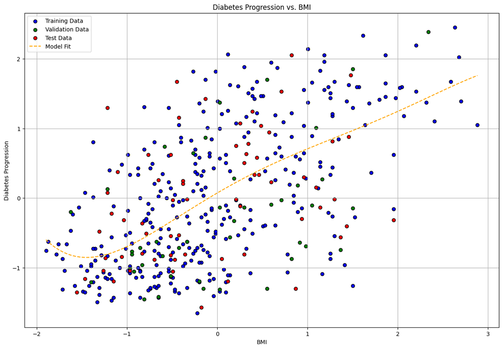

```python
# Plot the training, validation, and test data points
plt.figure(figsize=(15, 10))

# Plot the training data points
plt.scatter(X_train, y_train, color='blue', edgecolor='k', label='Training Data')

# Plot the validation data points
plt.scatter(X_val, y_val, color='green', edgecolor='k', label='Validation Data')

# Plot the test data points
plt.scatter(X_test, y_test, color='red', edgecolor='k', label='Test Data')

# Plot the model fit line
x_values = np.linspace(X.min(), X.max(), 100)
y_values = models_univariate_Polynomial[5].predict(poly_features.transform(x_values.reshape(-1, 1)))
plt.plot(x_values, y_values, color='orange', linestyle='--', label='Model Fit')

# Add labels and title
plt.title('Diabetes Progression vs. BMI')
plt.xlabel('BMI')
plt.ylabel('Diabetes Progression')
plt.legend()
plt.grid(True)
plt.show()
```

Overall in the graph we can see that many data points are far away from the fitted model line and we can say from observing this that the polynomial regression is not the correct model to use for this case.

#### Write down the equation of the best model (with a two decimal digit precision, assuming it's sufficient)

```python
# Extract the coefficients of the best model
coefficients = models_univariate_Polynomial[5].coef_
intercept = models_univariate_Polynomial[5].intercept_

# Format the coefficients and intercept
coefficients_str = " + ".join([f"{coef:.2f}*X^{i}" for i, coef in enumerate(coefficients.flatten(), start=1)])
equation = f"y = {coefficients_str} + {intercept[0]:.2f}"

# Print the equation of the best model
print(f"Equation of the Best Model: {equation}")
```

```
Equation of the Best Model: y = 0.76*X^1 + -0.12*X^2 + -0.05*X^3 + 0.05*X^4 + -0.01*X^5 + 0.07
```

#### Calculate the expected diabetes progression for a BMI value of your choice using `model.perdict()` for that value

```python
# Calculate the expected diabetes progression for a BMI value of .75
bmi_value = .75

# Transform the BMI value using the polynomial features
bmi_value_poly = poly_features.transform(np.array(bmi_value).reshape(-1, 1))

# Predict the diabetes progression
diabetes_progression = models_univariate_Polynomial[5].predict(bmi_value_poly)

# Print the expected diabetes progression
print(diabetes_progression)
```

```
[[0.56840926]]
```

#### How many trainable parameters are we fitting for each of the models? Explain these values. One way is to use sklearn function `get_feature_names_out()`

```python
# Get the feature names of the polynomial features
feature_names = poly_features.get_feature_names_out(input_features=['bmi'])

# Print the number of trainable parameters
print(f"Number of Trainable Parameters: {len(feature_names)}")

# Print the feature names
print(feature_names)
```

```
Number of Trainable Parameters: 5
['bmi' 'bmi^2' 'bmi^3' 'bmi^4' 'bmi^5']
```

Above is one example of the features used for fitting the model and this is the example of degree 5. similarly like this

- for degree 0 we would only have the intercept and it will predict same diabetes value for all bmi values
- for degree 1 we would have bmi with intercept which would create a straight line which can capture rate of change of target with respect to given featurea and gives equation as y = W1X + W2 here X is bmi
- for degree 2 we would have bmi bmi^2 and intercept which would create a parabolic curve which can captures the rate of acceleration or deacceleration with respect to given feature and gives equation as y = W1X + W2X^2 + W3 here X is bmi
- for degree 3 we would have bmi bmi^2 bmi^3 and intercept which would create a s shaped curve giving equation as y = W1X + W2X^2 + W3X^3 + W4 here X is bmi
- for degree 4 we whoud have bmi bmi^2 bmi^3 bmi^4 and intercept which would create a complex curve giving equation as y = W1X + W2X^2 + W3X^3 + W4X^4 + W5 here X is bmi
- for degree 5 we would have bmi bmi^2 bmi^3 bmi^4 bmi^5 and intercept which would create a even more complex curve and giving equation as y = W1X + W2X^2 + W3X^3 + W4X^4 + W5X^5 + W6 here X is bmi

#### Provide a conclusion section. In particular, do a deep dive on where the model fails, and add a short section in the conclusions that describes the model limitations. This should be in addition to summarizing it performance.

While considering even higher degrees, the actual relationship of the progression with respect to BMI was not captured by the polynomial regression models. These results illustrate that only BMI is not sufficient to model the progression of diabetes, and more features should be added in the future. In addition, poor generalizability and overfitting observed in the high-degree polynomial models suggest that this might not be the right model choice in this case.

#### Part - 3 In this part, use all features in the dataset.

##### Two polynomial models (degree > 1)

```python
#Two polynomial models (degrees >1, of your choice)

# Create a list to store the results
results = []

# Get the features and target
X=diabetes_data.drop(columns=['target'])
y=diabetes_data[['target']]


# First, split the data into training + validation (85%) and test set (15%)
X_train_val, X_test, y_train_val, y_test = train_test_split(X, y, test_size=0.15, random_state=42)

# Now, split the training + validation set into training (75%) and validation set (10%)
X_train, X_val, y_train, y_val = train_test_split(X_train_val, y_train_val, test_size=0.12, random_state=42)

# models list
models = []

#loop through the degrees
for degree in [2,3]:
    models.append(polynomial_fit(X=X_train, y=y_train, degree=degree, X_val=X_val, y_val=y_val))

# Create a DataFrame from the results
data = pd.DataFrame(results, columns=['Degree', 'R-Squared', 'MAE' , 'MAPE'])

# Display the results in a table
print(data)
```

```
   Degree  R-Squared       MAE        MAPE
0       2   0.093096  0.686539  200.140055
1       3  -2.316244  1.308026  430.983845
```

#### Identify the best model based on the table above.

The degree 2 model performs better overall and is a better representation of the data compared to the degree 3 model.

```python
# Identify the best model based on R2 (maximum R2 value)
best_model_r2 = data.loc[data['R-Squared'].idxmax()]
print("Best Model Based on R2:")
display(best_model_r2)

# Identify the best model based on MAE (minimum MAE value)
best_model_mae = data.loc[data['MAE'].idxmin()]
print("\nBest Model Based on MAE:")
display(best_model_mae)

# Identify the best model based on MAPE (minimum MAPE value)
best_model_mape = data.loc[data['MAPE'].idxmin()]
print("\nBest Model Based on MAPE:")
display(best_model_mape)
```

```
Best Model Based on R2:
```

```
Degree         2.000000
R-Squared      0.093096
MAE            0.686539
MAPE         200.140055
Name: 0, dtype: float64
```

```
Best Model Based on MAE:
```

```
Degree         2.000000
R-Squared      0.093096
MAE            0.686539
MAPE         200.140055
Name: 0, dtype: float64
```

```
Best Model Based on MAPE:
```

```
Degree         2.000000
R-Squared      0.093096
MAE            0.686539
MAPE         200.140055
Name: 0, dtype: float64
```

#### Run the chosen model on the test set and provide results (R-Squared, MAPE, MAE).

```python
# Run the best model on the test set and provide the results. Explain the results to your reader.
poly_features = PolynomialFeatures(degree=2, include_bias=False)

# Transform the features
X_train_poly = poly_features.fit_transform(X_train)

# Run the model on the test set
y_test_pred=models[0].predict(poly_features.transform(X_test))

# Calculate the metrics
mape = np.mean(np.abs((y_test - y_test_pred) / y_test)) * 100
r2 = r2_score(y_test, y_test_pred)
mae = mean_absolute_error(y_test, y_test_pred)

# Print the metrics
print(f"R-Squared: {r2:.4f}")
print(f"Mean Absolute Error: {mae:.4f}")
print(f"Mean Absolute Percentage Error: {mape:.4f}")
```

```
R-Squared: 0.2863
Mean Absolute Error: 0.5766
Mean Absolute Percentage Error: 222.8309
```

#### Write down the equation of the best model (with a two decimal digit precision, assuming it's sufficient) (1 point).

```python
# Extract the coefficients of the best model
coefficients = models[0].coef_
intercept = models[0].intercept_

# Get the feature names of the polynomial features
feature_names = poly_features.get_feature_names_out(input_features=X.columns)

# Format the coefficients with its respective feature and intercept
coefficients_str = " + ".join([f"{coef:.2f}*{feature}" for coef, feature in zip(coefficients.flatten(), feature_names)])
equation = f"y = {coefficients_str} + {intercept[0]:.2f}"


# Print the equation of the best model
print(f"Equation of the Best Model: {equation}")
```

[output not shown]

#### Calculate the expected diabetes progression for sample values of your choice using `model.perdict()` for that value.

```python
# Calculate the expected diabetes progression for a sample value
sample_input = np.array([[0.05, -0.04, 0.06, 0.02, -0.04, -0.03, 0.01, 0.02, -0.01]])

# Transform the sample input using the polynomial features
sample_values_poly = poly_features.transform(sample_input)

# Predict the diabetes progression
diabetes_progression = models[0].predict(sample_values_poly)

# Print the expected diabetes progression
print(f"Predicted Diabetes Progression for the sample input: {diabetes_progression[0][0]:.2f}")
```

```
Predicted Diabetes Progression for the sample input: -351187777952.85
```

#### How many trainable parameters are we fitting for each of the models? Explain these values. One way is to use sklearn function `get_feature_names_out()`

```python
# Get the feature names of the polynomial features
feature_names = poly_features.get_feature_names_out(input_features=X.columns)

# Print the number of trainable parameters
print(f"Number of Trainable Parameters: {len(feature_names)}")

# Print the feature names
print(feature_names)
```

```
Number of Trainable Parameters: 54
['age' 'sex' 'bmi' 'bp' 's1' 's3' 's4' 's5' 's6' 'age^2' 'age sex'
 'age bmi' 'age bp' 'age s1' 'age s3' 'age s4' 'age s5' 'age s6' 'sex^2'
 'sex bmi' 'sex bp' 'sex s1' 'sex s3' 'sex s4' 'sex s5' 'sex s6' 'bmi^2'
 'bmi bp' 'bmi s1' 'bmi s3' 'bmi s4' 'bmi s5' 'bmi s6' 'bp^2' 'bp s1'
 'bp s3' 'bp s4' 'bp s5' 'bp s6' 's1^2' 's1 s3' 's1 s4' 's1 s5' 's1 s6'
 's3^2' 's3 s4' 's3 s5' 's3 s6' 's4^2' 's4 s5' 's4 s6' 's5^2' 's5 s6'
 's6^2']
```

#### For degree 2

- Original Features: These are the primary features from the dataset, such as:
- 'age', 'sex', 'bmi', 'bp', 's1', 's3', 's4', 's5', 's6'.
- These are used directly in the model.
- Squared Terms: The model includes quadratic terms for each feature, such as:
- 'age^2', 'bmi^2', 'bp^2', 's1^2', etc.
- These represent the effect of each feature's squared value, which captures non-linear relationships between the individual feature and the target.
- Interaction Terms: These are combinations of two different features, where the product of their values is included as a feature:
- 'age sex', 'age bmi', 'bmi bp', 's1 s5', etc.
- Interaction terms capture how the relationship between two features jointly affects the target variable.

#### For degree 3

- Original Features: The same features from the original dataset: 'age', 'sex', 'bmi', 'bp', 's1', 's3', 's4', 's5', 's6'.
- Squared Terms (Degree 2): The quadratic terms like 'age^2', 'bmi^2', 'bp^2', etc., capture non-linear relationships in each individual feature.
- Cubic Terms (Degree 3):
- These terms represent each feature raised to the power of 3, such as 'age^3', 'bmi^3', 'bp^3', etc.
- These terms help capture even more intricate non-linear relationships within each individual feature.
- Interaction Terms (Degree 2 and 3):
- Second-degree interactions: These are the interactions between two different features already included in degree 2 (e.g., 'age sex', 'bmi bp', etc.).
- Third-degree interactions: These include the product of three different features or a feature multiplied by its squared counterpart. For instance, 'age bmi bp', 'bmi^2 bp', 'age sex s1', etc.
- These terms allow the model to capture the joint effect of three features or interactions between squared terms and other features.

#### Provide a conclusion section. In particular, do a deep dive on where the model fails, and add a short section in the conclusions that describes the model limitations. This should be in addition to summarizing it performance.

In summary, while multivariate polynomial regression can provide insights into the relationships between features and diabetes progression, the performance metrics reveal significant limitations in predictive accuracy. The models tested are insufficient for reliable predictions, suggesting that polynomial regression is not suitable for this case.

#### Two decision trees (e.g. consider changing the `max_depth` hyperparameter)

```python
# Train two decision tree models with different max_depth values
tree1 = DecisionTreeRegressor(max_depth=3)
tree2 = DecisionTreeRegressor(max_depth=5)

# Fit the models
tree1.fit(X_train, y_train)
tree2.fit(X_train, y_train)

# Predict on the validation set
y_val_pred1 = tree1.predict(X_val)
y_val_pred2 = tree2.predict(X_val)

# Calculate the performance metrics
r2_1 = r2_score(y_val, y_val_pred1)
mae_1 = mean_absolute_error(y_val, y_val_pred1)


r2_2 = r2_score(y_val, y_val_pred2)
mae_2 = mean_absolute_error(y_val, y_val_pred2)
# calculate the mape for decision tree 1 and 2
y_val_flat = y_val.values.flatten()


mape1 = np.mean(np.abs((y_val_flat - y_val_pred1) / y_val_flat)) * 100
mape2 = np.mean(np.abs((y_val_flat - y_val_pred2) / y_val_flat)) * 100

# Print the performance metrics
metrics = {
    "Metric": ["R-Squared", "Mean Absolute Error", "Mean Absolute Percentage Error"],
    "Decision Tree 1": [round(r2_1, 4), round(mae_1, 4), round(mape1, 4)],
    "Decision Tree 2": [round(r2_2, 4), round(mae_2, 4), round(mape2, 4)]
}

# Create a DataFrame from the dictionary
metrics_df = pd.DataFrame(metrics)

# Display the DataFrame
print(metrics_df)
```

```
                           Metric  Decision Tree 1  Decision Tree 2
0                       R-Squared           0.1623          -0.1801
1             Mean Absolute Error           0.7010           0.8177
2  Mean Absolute Percentage Error         264.7415         316.1757
```

Choose Decision Tree 1. It has better R-Squared, lower MAE, and lower MAPE, indicating it is the more reliable model for predicting the target variable in this case. Although the overall performance metrics are not ideal, Decision Tree 1 outperforms Decision Tree 2 across the board.

#### Run the best model on the test set and provide the results. Explain the results to your reader.

```python
# predict on the test set
y_test_pred1 = tree1.predict(X_test)

# Calculate the performance metrics
r2_test1 = r2_score(y_test, y_test_pred1)
mae_test1 = mean_absolute_error(y_test, y_test_pred1)

# calculate the mape for decision tree 1
y_test_flat = y_test.values.flatten()
mape_test1 = np.mean(np.abs((y_test_flat - y_test_pred1) / y_test_flat)) * 100

# Print the performance metrics
print("Decision Tree 1 Test Results:")
print(f"R-Squared: {r2_test1:.4f}")
print(f"Mean Absolute Error: {mae_test1:.4f}")
print(f"Mean Absolute Percentage Error: {mape_test1:.4f}")
```

```
Decision Tree 1 Test Results:
R-Squared: 0.0584
Mean Absolute Error: 0.6593
Mean Absolute Percentage Error: 307.4739
```

#### Calculate the expected diabetes progression for sample value of your choice using `model.perdict()` for that value

```python
# get sample input
sample_input = np.array([[0.05, -0.04, 0.06, 0.02, -0.04, -0.03, 0.01, 0.02, -0.01]])

# Predict the diabetes progression
sample_values = tree1.predict(sample_input)

# Print the diabetes progression
print(f"Predicted Diabetes Progression for the sample input: {sample_values[0]:.2f}")
```

```
Predicted Diabetes Progression for the sample input: -0.50
```

#### How many trainable parameters are we fitting for each of the models? Explain these values. One way is to use sklearn function `get_feature_names_out()` for decision tree

```python
# Get the trainable parameters for the decision tree models

n_leaves_tree1 = tree1.get_n_leaves()  # Number of leaves
n_nodes_tree1 = tree1.tree_.node_count  # Total number of nodes


n_leaves_tree2 = tree2.get_n_leaves()  # Number of leaves
n_nodes_tree2 = tree2.tree_.node_count  # Total number of nodes

# Print the results
print(f"Number of Trainable Parameters for tree 1 with max depth = 3 (Leaves): {n_leaves_tree1}")
print(f"Total Number of Nodes for tree 1 with max depth = 3: {n_leaves_tree1}")

print(f"Number of Trainable Parameters for tree 2 with max depth = 5 (Leaves): {n_leaves_tree2}")
print(f"Total Number of Nodes for tree 2 with max depth = 5: {n_leaves_tree2}")
```

[output not shown]

Explanation of Values Number of Leaves (n_leaves): Each leaf node represents a unique output prediction based on the input features. The more leaves, the more complex the model is, and this directly corresponds to the number of outcomes the model can predict.

Total Number of Nodes (n_nodes): This includes both internal nodes (where decisions are made) and leaf nodes. It gives an overall idea of the complexity of the tree. The internal nodes are where splits occur based on the feature thresholds, contributing to the model’s ability to fit the data.

#### Two kNNs

```python
# Train two kNN models with different n_neighbors values
knn1 = KNeighborsRegressor(n_neighbors=5)
knn2 = KNeighborsRegressor(n_neighbors=10)

# Fit the models
knn1.fit(X_train, y_train)
knn2.fit(X_train, y_train)

# Predict on the validation set
y_val_pred1 = knn1.predict(X_val)
y_val_pred2 = knn2.predict(X_val)

# Calculate the performance metrics
r2_1 = r2_score(y_val, y_val_pred1)
mae_1 = mean_absolute_error(y_val, y_val_pred1)
y_val_flat = y_val.values.flatten()
mape1 = np.mean(np.abs((y_val_flat - y_val_pred1) / y_val_flat)) * 100

r2_2 = r2_score(y_val, y_val_pred2)
mae_2 = mean_absolute_error(y_val, y_val_pred2)
mape2 = np.mean(np.abs((y_val_flat - y_val_pred2) / y_val_flat)) * 100

# Print the performance metrics
metrics = {
    "Metric": ["R-Squared", "Mean Absolute Error", "Mean Absolute Percentage Error"],
    "kNN 1": [round(r2_1, 4), round(mae_1, 4), round(mape1, 4)],
    "kNN 2": [round(r2_2, 4), round(mae_2, 4), round(mape2, 4)]
}

# Create a DataFrame from the dictionary
metrics_KNN_df = pd.DataFrame(metrics)

# Display the DataFrame
print(metrics_KNN_df)
```

```
                           Metric     kNN 1     kNN 2
0                       R-Squared    0.3346    0.3956
1             Mean Absolute Error    0.5957    0.5664
2  Mean Absolute Percentage Error  220.3776  206.2722
```

According to the performance metrics, kNN 2 is the better model to choose based on its higher R-Squared value and lower MAE and MAPE. This model demonstrates improved predictive accuracy and better representation of the data trends.

#### Run the best model on the test set and provide the results. Explain the results to your reader.

```python
# predict on the test set
y_test_pred1 = knn2.predict(X_test)

# Calculate the performance metrics
r2_test1 = r2_score(y_test, y_test_pred1)
mae_test1 = mean_absolute_error(y_test, y_test_pred1)

# calculate the mape for kNN 2
y_test_flat = y_test.values.flatten()
mape_test1 = np.mean(np.abs((y_test_flat - y_test_pred1) / y_test_flat)) * 100

# Print the performance metrics
print("kNN 2 Test Results:")
print(f"R-Squared: {r2_test1:.4f}")
print(f"Mean Absolute Error: {mae_test1:.4f}")
print(f"Mean Absolute Percentage Error: {mape_test1:.4f}")
```

```
kNN 2 Test Results:
R-Squared: 0.2722
Mean Absolute Error: 0.5873
Mean Absolute Percentage Error: 330.7665
```

While kNN 2 performed relatively better during validation, its performance on the test set highlights significant limitations

#### Calculate the expected diabetes progression for sample value of your choice using `model.perdict()` for that value

```python
# get sample input
sample_input = np.array([[0.05, -0.04, 0.06, 0.02, -0.04, -0.03, 0.01, 0.02, -0.01]])

# Predict the diabetes progression
sample_values = knn2.predict(sample_input)

# Print the diabetes progression
print(f"Predicted Diabetes Progression for the sample input: {sample_values[0][0]:.2f}")
```

```
Predicted Diabetes Progression for the sample input: 0.10
```

#### How many trainable parameters are we fitting for each of the models? Explain these values. One way is to use sklearn function `get_feature_names_out()`

```python
# Get the feature names of the KNN models
feature_names = X.columns

# Print the number of trainable parameters
print(f"Number of Trainable Parameters: {len(feature_names)}")

# Print the feature names
print(feature_names)
```

```
Number of Trainable Parameters: 9
Index(['age', 'sex', 'bmi', 'bp', 's1', 's3', 's4', 's5', 's6'], dtype='object')
```

While kNN does not have trainable parameters in the traditional sense, it utilizes all features in the training dataset to compute distances and make predictions. Therefore, it's essential to understand the features involved and ensure they are appropriately preprocessed.